# Riiid! Answer Correctness EDA and visualization

```python
import numpy as np # linear algebra
import pandas as pd # data processing, CSV file I/O (e.g. pd.read_csv)

import warnings
warnings.filterwarnings("ignore", category=DeprecationWarning)
warnings.filterwarnings("ignore", category=UserWarning)
warnings.filterwarnings("ignore", category=FutureWarning)

import os
for dirname, _, filenames in os.walk('/kaggle/input'):
    for filename in filenames:
        print(os.path.join(dirname, filename))
```

```
/kaggle/input/riiid-test-answer-prediction/lectures.csv
/kaggle/input/riiid-test-answer-prediction/example_test.csv
/kaggle/input/riiid-test-answer-prediction/example_sample_submission.csv
/kaggle/input/riiid-test-answer-prediction/train.csv
/kaggle/input/riiid-test-answer-prediction/questions.csv
/kaggle/input/riiid-test-answer-prediction/riiideducation/__init__.py
/kaggle/input/riiid-test-answer-prediction/riiideducation/competition.cpython-37m-x86_64-linux-gnu.so
```

## Exploratory Data Analysis

### 1. train.csv

From the description of the dataset, we have the following for reference

- **row_id**: (int64) ID code for the row.
- **timestamp**: (int64) the time in milliseconds between this user interaction and the first event completion from that user.
- **user_id**: (int32) ID code for the user.
- **content_id**: (int16) ID code for the user interaction
- **content_type_id**: (int8) 0 if the event was a question being posed to the user, 1 if the event was the user watching a lecture.
- **task_container_id**: (int16) Id code for the batch of questions or lectures. For example, a user might see three questions in a row before seeing the explanations for any of them. Those three would all share a task_container_id.
- **user_answer**: (int8) the user's answer to the question, if any. Read -1 as null, for lectures.
- **answered_correctly**: (int8) if the user responded correctly. Read -1 as null, for lectures.
- **prior_question_elapsed_time**: (float32) The average time in milliseconds it took a user to answer each question in the previous question bundle, ignoring any lectures in between. Is null for a user's first question bundle or lecture. Note that the time is the average time a user took to solve each question in the previous bundle.
- **prior_question_had_explanation**: (bool) Whether or not the user saw an explanation and the correct response(s) after answering the previous question bundle, ignoring any lectures in between. The value is shared across a single question bundle, and is null for a user's first question bundle or lecture. Typically the first several questions a user sees were part of an onboarding diagnostic test where they did not get any feedback.

```python
train_df = pd.read_csv('/kaggle/input/riiid-test-answer-prediction/train.csv',
                       low_memory=False,
                       nrows=1e6,
                       dtype={'row_id': 'int64',
                              'timestamp': 'int64',
                              'user_id': 'int32',
                              'content_id': 'int16',
                              'content_type_id': 'int8',
                              'task_container_id': 'int16',
                              'user_answer': 'int8',
                              'answered_correctly': 'int8',
                              'prior_question_elapsed_time': 'float32',
                              'prior_question_had_explanation': 'boolean',
                             }
                      )
train_df.head()
```

|  | row_id | timestamp | user_id | content_id | content_type_id | task_container_id | user_answer | answered_correctly | prior_question_elapsed_time | prior_question_had_explanation |
| --- | --- | --- | --- | --- | --- | --- | --- | --- | --- | --- |
| 0 | 0 | 0 | 115 | 5692 | 0 | 1 | 3 | 1 | NaN | <NA> |
| 1 | 1 | 56943 | 115 | 5716 | 0 | 2 | 2 | 1 | 37000.0 | False |
| 2 | 2 | 118363 | 115 | 128 | 0 | 0 | 0 | 1 | 55000.0 | False |
| 3 | 3 | 131167 | 115 | 7860 | 0 | 3 | 0 | 1 | 19000.0 | False |
| 4 | 4 | 137965 | 115 | 7922 | 0 | 4 | 1 | 1 | 11000.0 | False |

##### 1.1 Missing Data

Let's examine the missing values.

```python
for column in train_df.columns:
    if train_df[column].isna().sum() != 0:
        print("{} has: {:,} missing values. ({:.2}%)".format(column,
                                            train_df[column].isna().sum(),
                                            (train_df[column].isna().sum()/len(train_df))*100))
```

```
prior_question_elapsed_time has: 23,723 missing values. (2.4%)
prior_question_had_explanation has: 3,816 missing values. (0.38%)
```

Two columns (`prior_question_elapsed_time`, `prior_question_had_explanation`) have missing values, and it is explained in the documentation that NULL values are presented for the first question bundle or lecture purpose.

#### 1.2 Individual features analysis

- categorical features(small range): `user_answer`(int8), `answered_correctly`(int8), `content_type_id`(int8), `prior_question_had_explanation`(bool)
- categorical features(large range): `user_id`, `content_id`, `task_container_id`
- numerical features: `timestamp`, `prior_question_elapsed_time`

```python
import seaborn as sns
import matplotlib.pyplot as plt
%matplotlib inline
import matplotlib.image as mpimg
```

```python
def barplot(df, feature, title):
    vc = df[feature].value_counts().reset_index()
    idx = vc["index"].values
    vals = vc[feature].values

    plt.figure(figsize = (7, 5))
    sns.barplot(idx, vals)
    plt.title(title, fontsize=13)
    plt.show()

    del idx, vals
    return
```

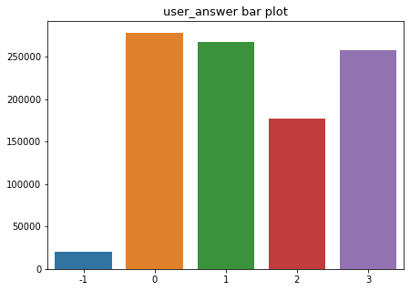

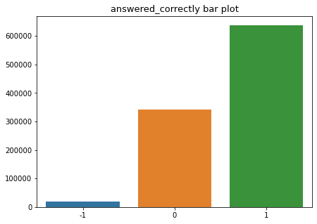

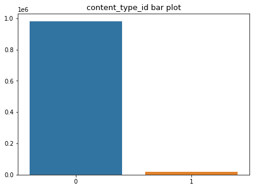

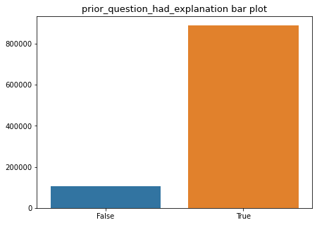

```python
bar_plot_features = ["user_answer", "answered_correctly", "content_type_id", "prior_question_had_explanation"]

for feature in bar_plot_features:
    barplot(train_df, feature, feature+" bar plot")
```

- For `user_answer` and `answer_correctly`, there is few cases that is Null for lectures.
- `content_type`=1 indicates that is lectures and it does not need to be included in the prediction.
- `answer_correctly` is not balanced in a way that the answer correctly cases is more than the answer incorrectly cases.

```python
def distplot_categorical(df, feature):
    values = df[feature].value_counts().values

    print("Summary of {}\nMean: {}\nMedian: {}\nMax:{}".format(feature,
                                                                np.mean(values),
                                                                np.median(values),
                                                                np.max(values)))

    plt.figure(figsize=(18, 5))
    sns.distplot(values, hist = False, kde_kws = {'lw':3})
    plt.title("Count distribution plot of " + feature, fontsize=15)
    plt.show()

    del values
    return
```

```
Summary of user_id
Mean: 261.5062761506276
Median: 41.5
Max:10826
```

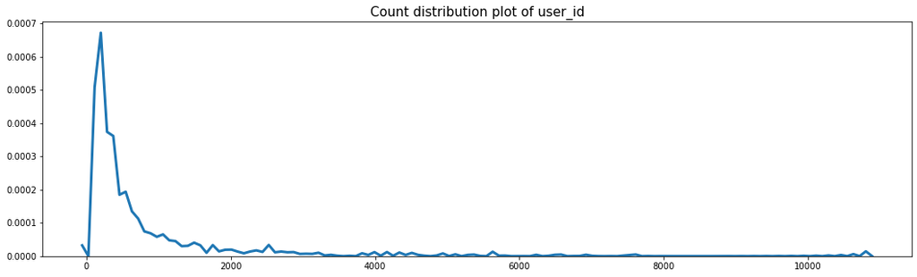

```
Summary of content_id
Mean: 75.07507507507508
Median: 49.0
Max:2041
```

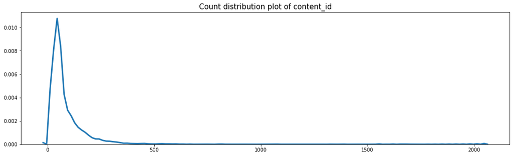

```
Summary of task_container_id
Mean: 129.19896640826875
Median: 23.0
Max:7845
```

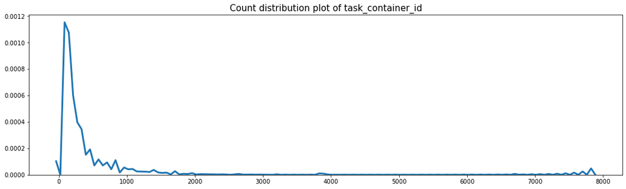

```python
categorical_features = ["user_id", "content_id", "task_container_id"]

for feature in categorical_features:
    distplot_categorical(train_df, feature)
```

```python
def distplot_numerical(df, feature):
    values = df[feature].values

    plt.figure(figsize=(18, 5))
    sns.distplot(values, hist = False, kde_kws = {'lw':3})
    plt.title("distribution plot of " + feature, fontsize=15)
    plt.show()

    del values
    return
```

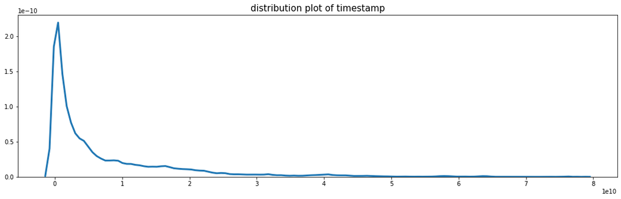

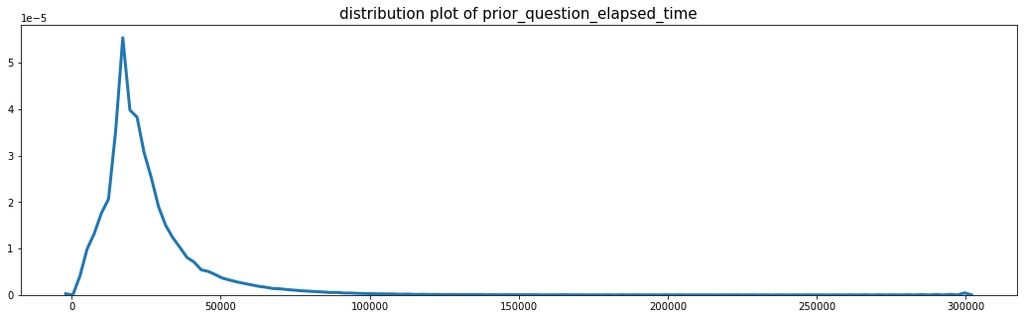

```python
numerical_features = ["timestamp", "prior_question_elapsed_time"]
for feature in numerical_features:
    distplot_numerical(train_df, feature)
```

- We can see most of the prior_question_elapsed_time are around 0 to 50000.

### 1.3 Outliers

For example, we want to get rid of all users that have less than 5 interactions in the dataset because the record is too short to use it for prediction.

```python
vc = train_df["user_id"].value_counts().reset_index()
idxs = vc[vc["user_id"] < 5]["index"].values
idx_rows = train_df["user_id"].isin(idxs)
new_train_df = train_df[~idx_rows]

print("Percentage of erased data: {:,.3}%".format(len(idxs)*100/len(train_df)))

del vc, idxs, idx_rows
```

```
Percentage of erased data: 0.0005%
```

### 1.4 Correlation

```python
new_train_df.head()
```

|  | row_id | timestamp | user_id | content_id | content_type_id | task_container_id | user_answer | answered_correctly | prior_question_elapsed_time | prior_question_had_explanation |
| --- | --- | --- | --- | --- | --- | --- | --- | --- | --- | --- |
| 0 | 0 | 0 | 115 | 5692 | 0 | 1 | 3 | 1 | NaN | <NA> |
| 1 | 1 | 56943 | 115 | 5716 | 0 | 2 | 2 | 1 | 37000.0 | False |
| 2 | 2 | 118363 | 115 | 128 | 0 | 0 | 0 | 1 | 55000.0 | False |
| 3 | 3 | 131167 | 115 | 7860 | 0 | 3 | 0 | 1 | 19000.0 | False |
| 4 | 4 | 137965 | 115 | 7922 | 0 | 4 | 1 | 1 | 11000.0 | False |

```python
new_train_df.loc[:,"prior_question_elapsed_time"] = new_train_df.loc[
    :,"prior_question_elapsed_time"].fillna(-1)
new_train_df.loc[:,"prior_question_had_explanation"] = new_train_df.loc[:,
    "prior_question_had_explanation"].replace({False: 0, True: 1, np.nan: -1})
```

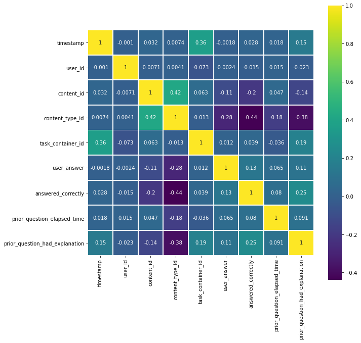

```python
corr = new_train_df.set_index("row_id").corr()
f, ax = plt.subplots(figsize=(10, 10))
ax = sns.heatmap(corr,square=True,linewidths=.8,
                     cmap="viridis",annot=True)
```

- `timestamp` is correlated with `task_container_id` and `prior_question_had_explanation`
- `content_id` is correlated with `content_type_id` showing that they are somehow related.
- `prior_question_had_explanation` has positive correlation `answered_correctly`, implying that the explanation may help the pupils learn better. Together with the correlation with `timestamp`, it may indicate that the longer usage of the platform results in better performance.

### 2. Question.csv

Metadata for the questions posed to users.

- `question_id`: foreign key for the train/test content_id column, when the content type is question (0).
- `bundle_id`: code for which questions are served together.
- `correct_answer`: the answer to the question. Can be compared with the train user_answer column to check if the user was right.
- `part`: the relevant section of the TOEIC test.
- `tags`: one or more detailed tag codes for the question. The meaning of the tags will not be provided, but these codes are sufficient for clustering the questions together.

```python
question_df = pd.read_csv('../input/riiid-test-answer-prediction/questions.csv')
question_df.head()
```

|  | question_id | bundle_id | correct_answer | part | tags |
| --- | --- | --- | --- | --- | --- |
| 0 | 0 | 0 | 0 | 1 | 51 131 162 38 |
| 1 | 1 | 1 | 1 | 1 | 131 36 81 |
| 2 | 2 | 2 | 0 | 1 | 131 101 162 92 |
| 3 | 3 | 3 | 0 | 1 | 131 149 162 29 |
| 4 | 4 | 4 | 3 | 1 | 131 5 162 38 |

```python
for column in question_df.columns:
    if question_df[column].isna().sum() != 0:
        print("{} has: {:,} missing values. ({:.2}%)".format(column,
                                            question_df[column].isna().sum(),
                                            (question_df[column].isna().sum()/len(question_df))*100))
```

```
tags has: 1 missing values. (0.0074%)
```

Categorical features: `question_id`, `bundle_id`, `correct_anser`, `part`, `tags`

```python
print("Total (unique)question ID: {:,}".format(question_df["question_id"].nunique()))
print("Number of unique bundle IDs: {:,}".format(question_df["bundle_id"].nunique()))
```

```
Total (unique)question ID: 13,523
Number of unique bundle IDs: 9,765
```

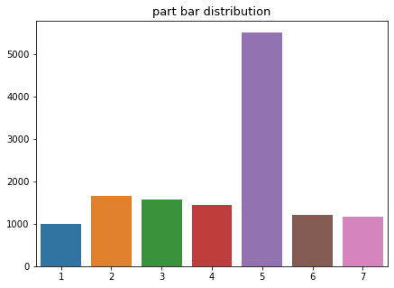

```python
barplot(question_df, "part", "part bar distribution")
```

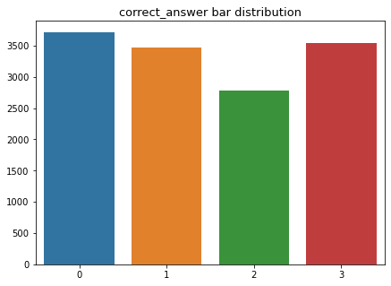

```python
barplot(question_df, "correct_answer", "correct_answer bar distribution")
```

```
Summary of tags
Mean: 8.901909150757078
Median: 2.0
Max:738
```

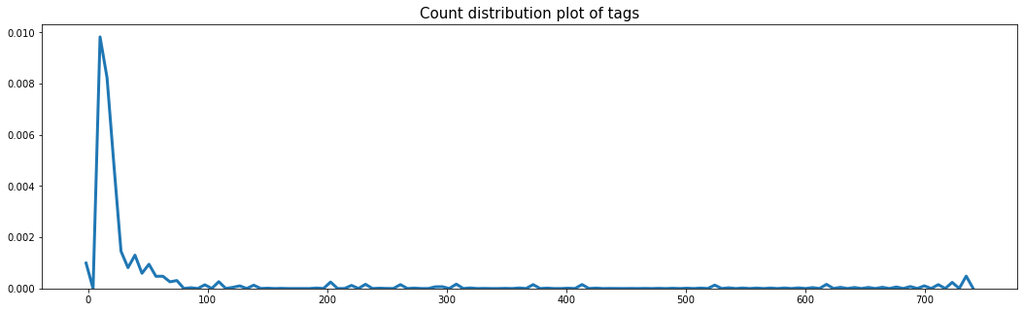

```python
distplot_categorical(question_df, "tags")
```

- Look carefully at the tags column, each of it consists of multiple tags seperated by space, which may need further treatment on this column.

### 3. lectures.csv

Metadata for the lectures watched by users as they progress in their education.

- `lecture_id`: foreign key for the train/test content_id column, when the content type is lecture (1).
- `part`: top level category code for the lecture.
- `tag`: one tag codes for the lecture. The meaning of the tags will not be provided, but these codes are sufficient for clustering the lectures together.
- `type_of`: brief description of the core purpose of the lecture

```python
lecture_df = pd.read_csv("../input/riiid-test-answer-prediction/lectures.csv")
lecture_df.head()
```

|  | lecture_id | tag | part | type_of |
| --- | --- | --- | --- | --- |
| 0 | 89 | 159 | 5 | concept |
| 1 | 100 | 70 | 1 | concept |
| 2 | 185 | 45 | 6 | concept |
| 3 | 192 | 79 | 5 | solving question |
| 4 | 317 | 156 | 5 | solving question |

```python
for column in lecture_df.columns:
    if lecture_df[column].isna().sum() != 0:
        print("{} has: {:,} missing values. ({:.2}%)".format(column,
                                            lecture_df[column].isna().sum(),
                                            (lecture_df[column].isna().sum()/len(lecture_df))*100))
```

No missing value!

```python
print("Total (unique)lecture ID: {:,}".format(lecture_df["lecture_id"].nunique()))
print("Number of unique tag IDs: {:,}".format(lecture_df["tag"].nunique()))
```

```
Total (unique)lecture ID: 418
Number of unique tag IDs: 151
```

- If we look into the dataset, `Tag` in this dataframe is segmented compared to the one in the `questions` dataframe. Not sure if they are related

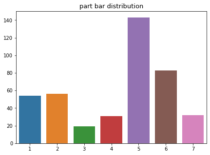

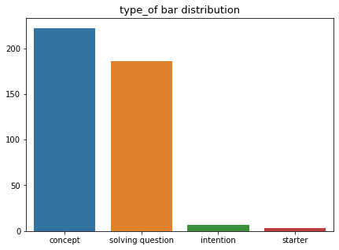

```python
for feature in ['part', 'type_of']:
    barplot(lecture_df, feature, feature + " bar distribution")
```

- Similar to `questions`, part 5 has a outstanding number of occurence.

### 4. example_test.csv

```python
exampleTest_df = pd.read_csv("../input/riiid-test-answer-prediction/example_test.csv")
exampleTest_df["prior_group_responses"].unique()
```

```
array(['[]', nan,
       '[0, 0, 1, 1, 0, 1, 3, 3, 1, 1, 0, 3, 1, 2, 2, 1, 0, 3]',
       '[1, 2, 2, 2, 1, 0, 1, 2, 1, 1, 3, 2, 0, 0, 3, 1, 1, 3, 3, 3, 0, 0, 0, 1, 2, 0, 3]',
       '[0, 1, 0, 0, 1, 1, 0, 0, 1, 1, 1, 0, 3, 0, 0, 0, 0, 0, 0, 3, 0, 0, 0, 0, 0, 1]'],
      dtype=object)
```

Some takeaways from the description:

- Three sample groups of the test set data as it will be delivered by the time-series API
- Some users will appear in the hidden test set that have NOT been presented in the train set
- Expect to see roughly 2.5 million questions in the hidden test set.

Metadata description:

- `prior_group_responses` (string) provides all of the user_answer entries for previous group in a string representation of a list in the first row of the group. All other rows in each group are null. If you are using Python, you will likely want to call eval on the non-null rows. Some rows may be null, or empty lists.
- `prior_group_answers_correct` (string) provides all the answered_correctly field for previous group, with the same format and caveats as prior_group_responses. Some rows may be null, or empty lists.

### 5. Modeling

```python
from sklearn.model_selection import train_test_split
from sklearn.metrics import roc_auc_score
from sklearn.preprocessing import StandardScaler
```

```python
# Exclude lectures rows for now
new_train_df = new_train_df[new_train_df['content_type_id'] != 1]
new_train_df = new_train_df[new_train_df['answered_correctly'] != -1].reset_index(drop=True)
lecture_user_content_df = new_train_df[new_train_df['content_type_id'] == 1]
```

### 5.1 Prepare Data and Feature Engineering

#### a) Preprocessing the occurence of the user_id and the content_id

```python
features_picked = ['timestamp', 'user_id', 'content_id', 'prior_question_elapsed_time',
                  'prior_question_had_explanation', 'answered_correctly']
target = 'answered_correctly'
```

```python
new_train_df = new_train_df[features_picked]
```

```python
percent_for_feature = 0.9
features_df = new_train_df.iloc[:int(percent_for_feature * len(new_train_df))]
train_df = new_train_df.iloc[int(percent_for_feature * len(new_train_df)):]
```

```python
user_answers_df = features_df[features_df['answered_correctly'] != -1].groupby('user_id').\
                agg({'answered_correctly': ['sum', 'count', 'min',
                                           'max', 'median','var']}).reset_index()
user_answers_df.columns = ['user_id', 'user_sum', 'user_count', 'user_min',
                       'user_max', 'user_median', 'user_var']


content_answers_df = features_df[features_df['answered_correctly'] != -1].groupby('content_id').\
                agg({'answered_correctly': ['sum', 'count', 'min',
                                           'max', 'median', 'var']}).reset_index()
content_answers_df.columns = ['content_id', 'content_sum', 'content_count', 'content_min',
                       'content_max', 'content_median', 'content_var']
```

#### b) Combine and clean data

```python
def combine_fillna_features_df(train_df):
    train_df = train_df[train_df[target] != -1]

    train_df = train_df.merge(user_answers_df, how='left', on='user_id')
    train_df = train_df.merge(content_answers_df, how='left', on='content_id')

    train_df['prior_question_had_explanation'] = train_df['prior_question_had_explanation'].astype(int)

    train_df.fillna(value = -1, inplace = True)
    return train_df
```

```python
features_for_ML = ['user_sum', 'user_count', 'user_min', 'user_max', 'user_median', 'user_var',
                  'content_sum', 'content_count', 'content_min','content_max', 'content_median',
                  'content_var',
                  'prior_question_elapsed_time',
                  'prior_question_had_explanation', 'answered_correctly']
train = combine_fillna_features_df(train_df)
train = train[features_for_ML]
train.head()
```

|  | user_sum | user_count | user_min | user_max | user_median | user_var | content_sum | content_count | content_min | content_max | content_median | content_var | prior_question_elapsed_time | prior_question_had_explanation | answered_correctly |
| --- | --- | --- | --- | --- | --- | --- | --- | --- | --- | --- | --- | --- | --- | --- | --- |
| 0 | 701.0 | 2255.0 | 0.0 | 1.0 | 0.0 | 0.214323 | 52.0 | 54.0 | 0.0 | 1.0 | 1.0 | 0.036338 | 1400.0 | 1 | 0 |
| 1 | 701.0 | 2255.0 | 0.0 | 1.0 | 0.0 | 0.214323 | 47.0 | 54.0 | 0.0 | 1.0 | 1.0 | 0.114955 | 1400.0 | 1 | 0 |
| 2 | 701.0 | 2255.0 | 0.0 | 1.0 | 0.0 | 0.214323 | 67.0 | 99.0 | 0.0 | 1.0 | 1.0 | 0.220985 | 1600.0 | 1 | 0 |
| 3 | 701.0 | 2255.0 | 0.0 | 1.0 | 0.0 | 0.214323 | 61.0 | 99.0 | 0.0 | 1.0 | 1.0 | 0.238920 | 1600.0 | 1 | 0 |
| 4 | 701.0 | 2255.0 | 0.0 | 1.0 | 0.0 | 0.214323 | 45.0 | 99.0 | 0.0 | 1.0 | 0.0 | 0.250464 | 1600.0 | 1 | 0 |

#### c) Training model

```python
from sklearn.model_selection import train_test_split
target = features_for_ML.pop(-1)
X = train[features_for_ML]
y = train[target]

X_train, X_test, y_train, y_test = train_test_split(X, y, test_size=0.3, shuffle=True,
                                                    random_state=2, stratify=y)
```

```python
import xgboost as xgb
```

```python
def train_xgb_model(X_train, X_test, y_train, y_test, params, detail=None, printRes=True):
    # Train an XGB model and return trained model + ROC score

    train_matrix = xgb.DMatrix(data = X_train, label = y_train)

    model = xgb.train(params, dtrain = train_matrix)

    predicts = model.predict(xgb.DMatrix(X_test))
    roc = roc_auc_score(y_test, predicts)

    if printRes:
        print("{} - ROC: {:,.5}".format(detail, roc))

    return model, roc
```

```python
baseline_params = {
    'max_depth': 4,
    'max_leaves': 2**4,
    'tree_method': 'hist',
    'grow_policy': 'lossguide',
    'objective': 'binary:logistic'
}

baseline_model, roc = train_xgb_model(X_train, X_test, y_train, y_test,
                                     baseline_params, detail = "baseline model")
```

```
baseline model - ROC: 0.71641
```

```python
# tuning eta-learning rate

rocs_eta = []
etas = [0.001, 0.005, 0.01, 0.1, 0.2, 0.3, 0.4, 0.5, 0.6]

for eta in etas:
    params = {
        'max_depth': 4,
        'max_leaves': 2**4,
        'tree_method': 'hist',
        'grow_policy': 'lossguide',
        'objective': 'binary:logistic',
        'eta': eta
    }

    model, roc = train_xgb_model(X_train, X_test, y_train, y_test,
                                params, detail = f"eta: {eta}")
    rocs_eta.append(roc)
```

```
eta: 0.001 - ROC: 0.70884
eta: 0.005 - ROC: 0.70924
eta: 0.01 - ROC: 0.71199
eta: 0.1 - ROC: 0.71464
eta: 0.2 - ROC: 0.71556
eta: 0.3 - ROC: 0.71641
eta: 0.4 - ROC: 0.71649
eta: 0.5 - ROC: 0.71637
eta: 0.6 - ROC: 0.71578
```

```python
# tuning Max depth of single tree

rocs_maxdepth = []
max_depths = [4, 5, 6, 7, 8, 9]

for depth in max_depths:
    params = {
        'max_depth': depth,
        'max_leaves': 2**4,
        'tree_method': 'hist',
        'grow_policy': 'lossguide',
        'objective': 'binary:logistic',
        'eta': 0.3
    }

    model, roc = train_xgb_model(X_train, X_test, y_train, y_test,
                                params, detail = f"Max depth: {depth}")
    rocs_eta.append(roc)
```

```
Max depth: 4 - ROC: 0.71641
Max depth: 5 - ROC: 0.71639
Max depth: 6 - ROC: 0.71639
Max depth: 7 - ROC: 0.71654
Max depth: 8 - ROC: 0.7164
Max depth: 9 - ROC: 0.7164
```

```python
f_params = {
    'max_depth': 8,
    'max_leaves': 2**4,
    'tree_method': 'hist',
    'grow_policy': 'lossguide',
    'objective': 'binary:logistic',
    'eta': 0.3
}

f_model, f_roc = train_xgb_model(X_train, X_test, y_train, y_test,
                                params, detail = 'Final model')
```

```
Final model - ROC: 0.7164
```

Final model - ROC: 0.7164

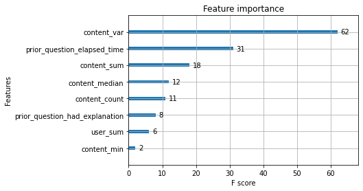

```python
xgb.plot_importance(f_model)
```

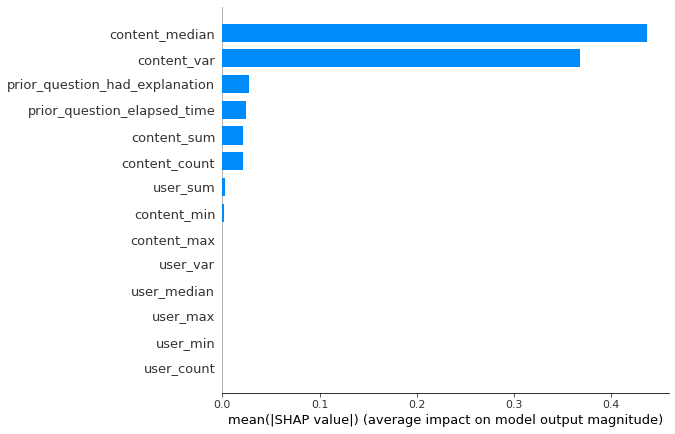

```python
import shap

explainer = shap.TreeExplainer(f_model)
shap_values = explainer.shap_values(X_test)

shap.summary_plot(shap_values, X_test, plot_type="bar", title = "")
```

### 6. Submission

```python
import riiideducation
#env = riiideducation.make_env()
```

```python
iter_test = env.iter_test()

for test_df, sample_prediction_df in iter_test:

    # preprocessing
    test_df = combine_fillna_features_df(data=test_df)
    X = test_df[features_for_ML]


    #Model
    test_Dmatrix = xgb.DMatrix(data=X)
    test_df['answered_correctly'] = f_model.predict(test_Dmatrix)
    env.predict(test_df.loc[test_df['content_type_id'] == 0, ['row_id', 'answered_correctly']])
```